# HW5

Parnian kassraie - 93111185

November 1, 2016

```r
#Libraries
library(readxl)
library(mosaic)
library(dplyr)
library(highcharter)
library(magrittr)
library(lmtest)
library(car)
library(corrplot)
library(DAAG)
library(bootstrap)
```

```r
#Data
auto=read.csv("data/ToyotaCorolla.csv")
car=read_excel("data/ToyotaCorolla.xls",sheet = 1)
field=read_excel("data/ToyotaCorolla.xls",sheet = 2)
car$Fuel_Type = as.factor(car$Fuel_Type)
car$Color=as.factor(car$Color)
colnames(car)[4]="Age"
```

## 1. A Matrix of Plots

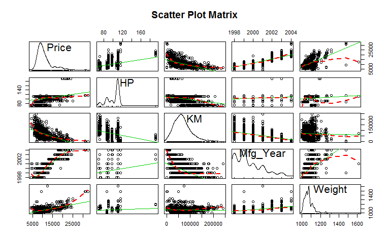

```r
# Scatterplot Matrices
scatterplotMatrix(~Price+HP+KM+Mfg_Year+Weight, data=car,
                  spread=FALSE, smoother.args=list(lty=2),
                  main="Scatter Plot Matrix")
```

## 2. Correlation Matrix & Variable Selection

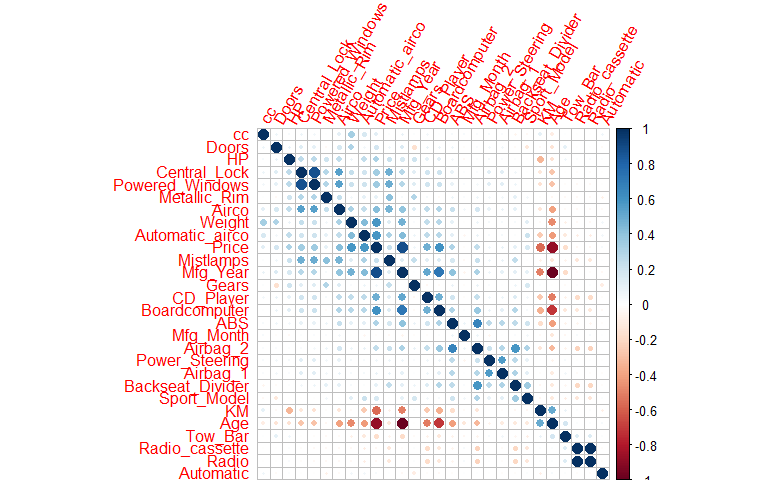

```r
M=cor(car[c(3,4,5,6,7,9,12,13,14,16,18,22:38)])
corrplot(M,tl.srt=60,order = "AOE")
```

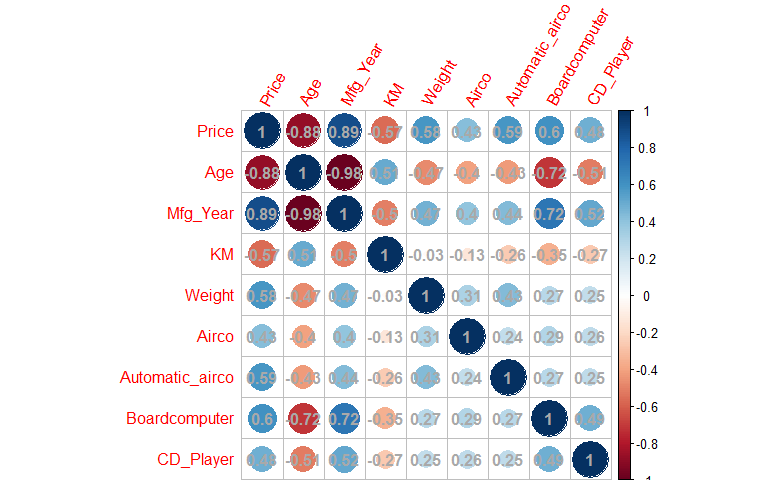

```r
M2=cor(car[c(3,4,6,7,18,25,26,27,28)])
corrplot(M2,tl.srt=60,addCoef.col = "darkgray")
```

Most significant features in determining car price:

| Variable | Correlation With Price |
| --- | --- |
| Age | -0.8765905 |
| Mfg-Year | 0.8851592 |
| KM | -0.56996016 |
| Weight | 0.58119759 |
| Airco | 0.4292594 |
| Automatic-airco | 0.5882620 |
| Boardcomputer | 0.6012920 |
| CD-Player | 0.4813744 |

Above, the variables with an absolute correlation value more that 0.3 are listed. Other variables are either coded in these ones or are irrelevant to the cars’ prices. Note that how Age and Manufacturing year are similar.

## 3. Fitting A linear Model

```r
fit<-lm(Price~.-Model-Id-Age,car)
summary(fit)
```

```
##
## Call:
## lm(formula = Price ~ . - Model - Id - Age, data = car)
##
## Residuals:
##     Min      1Q  Median      3Q     Max
## -8007.7  -626.1   -38.4   635.7  5378.0
##
## Coefficients: (1 not defined because of singularities)
##                    Estimate Std. Error t value Pr(>|t|)
## (Intercept)      -2.849e+06  8.284e+04 -34.395  < 2e-16 ***
## Mfg_Month         2.323e+01  9.121e+00   2.547 0.010971 *
## Mfg_Year          1.421e+03  4.157e+01  34.192  < 2e-16 ***
## KM               -1.642e-02  1.128e-03 -14.559  < 2e-16 ***
## Fuel_TypeDiesel   9.718e+02  3.203e+02   3.034 0.002455 **
## Fuel_TypePetrol   2.051e+03  3.282e+02   6.247 5.55e-10 ***
## HP                1.965e+01  3.115e+00   6.308 3.79e-10 ***
## Met_Color        -7.090e+01  7.080e+01  -1.001 0.316782
## ColorBlack        5.683e+02  6.446e+02   0.882 0.378096
## ColorBlue         4.855e+02  6.437e+02   0.754 0.450831
## ColorGreen        2.374e+02  6.449e+02   0.368 0.712774
## ColorGrey         6.215e+02  6.441e+02   0.965 0.334715
## ColorRed          3.605e+02  6.442e+02   0.560 0.575827
## ColorSilver       5.432e+02  6.489e+02   0.837 0.402646
## ColorViolet       7.487e+01  8.523e+02   0.088 0.930014
## ColorWhite       -2.809e+02  6.741e+02  -0.417 0.676926
## ColorYellow       1.267e+02  9.043e+02   0.140 0.888574
## Automatic         3.526e+02  1.343e+02   2.627 0.008717 **
## cc               -1.077e-01  7.682e-02  -1.402 0.161269
## Doors             4.868e+01  3.567e+01   1.365 0.172507
## Cylinders                NA         NA      NA       NA
## Gears             1.492e+02  1.749e+02   0.853 0.393692
## Quarterly_Tax     1.422e+01  1.617e+00   8.793  < 2e-16 ***
## Weight            1.071e+01  1.141e+00   9.386  < 2e-16 ***
## Mfr_Guarantee     2.408e+02  6.501e+01   3.704 0.000221 ***
## BOVAG_Guarantee   4.890e+02  1.118e+02   4.373 1.32e-05 ***
## Guarantee_Period  6.407e+01  1.206e+01   5.311 1.27e-07 ***
## ABS              -2.352e+02  1.128e+02  -2.086 0.037178 *
## Airbag_1          7.561e+01  2.202e+02   0.343 0.731317
## Airbag_2         -1.124e+02  1.149e+02  -0.978 0.328025
## Airco             2.192e+02  7.901e+01   2.774 0.005614 **
## Automatic_airco   2.398e+03  1.669e+02  14.370  < 2e-16 ***
## Boardcomputer    -2.915e+02  1.040e+02  -2.802 0.005142 **
## CD_Player         2.040e+02  8.787e+01   2.322 0.020378 *
## Central_Lock     -9.760e+01  1.263e+02  -0.773 0.439831
## Powered_Windows   4.018e+02  1.263e+02   3.180 0.001503 **
## Power_Steering   -4.783e-01  2.488e+02  -0.002 0.998467
## Radio             5.636e+02  6.494e+02   0.868 0.385604
## Mistlamps        -6.094e+01  9.629e+01  -0.633 0.526939
## Sport_Model       2.913e+02  7.767e+01   3.750 0.000184 ***
## Backseat_Divider -2.614e+02  1.137e+02  -2.300 0.021598 *
## Metallic_Rim      2.192e+02  8.409e+01   2.607 0.009242 **
## Radio_cassette   -6.571e+02  6.497e+02  -1.011 0.311992
## Tow_Bar          -1.913e+02  6.995e+01  -2.735 0.006324 **
## ---
## Signif. codes:  0 '***' 0.001 '**' 0.01 '*' 0.05 '.' 0.1 ' ' 1
##
## Residual standard error: 1100 on 1393 degrees of freedom
## Multiple R-squared:  0.9108, Adjusted R-squared:  0.9081
## F-statistic: 338.6 on 42 and 1393 DF,  p-value: < 2.2e-16
```

The variable *Id* specifically explains all the variations in the data, since there’s a 1-1 mapping between Id and price, So I’m omitting this variable.

In addition, I’ll be ommition the variable *Model*, since it may violate the Independence assumption. The prices of the cars with the same model are rather correlated and increase the autocorrelation matrix values.

The variable *Age* and *Mfg-Year* are basically the same thing, So one of them is ommited as well.

## 4. Actual Price vs. Predicted Price

```r
highchart() %>%
  hc_add_series_scatter(x=car$Id,y=car$Price,name = "Actual Prices",showInLegend = T) %>%
  hc_add_series_scatter(x=car$Id,y=fitted(fit),name = "Estimated Prices",showInLegend = T) %>%
  hc_title(text="Comparision of Car Prices & Model Estimated Prices") %>%
  hc_yAxis(title = list(text = "Prices ($)")) %>%
  hc_xAxis(title = list(text = "Car ID"))
```

[interactive chart not shown]

```r
highchart() %>%
  hc_add_series_scatter(x=car$Price,y=round(fitted(fit)),name="Linear Model",showInLegend = T) %>%
  hc_title(text="Car Prices vs. Model Estimated Prices") %>%
  hc_yAxis(title = list(text = "Estimated Price")) %>%
  hc_xAxis(title = list(text = "Actual Price")) %>%
  hc_add_series_scatter(x=car$Price,y=car$Price,name="Actual Data Points",showInLegend = T)
```

[interactive chart not shown]

We expect the scatters in the second plot to be a 45 degree line, like the gray one drawn. There aren’t many outliers and the data is distributed equally around the theoretical line. Also, the intercept and the slop is similar to what we expected.

It seems that the model fits the data really well.

## 5. R-squared

```r
#Manually:
Est=round(fitted(fit))
car2<-car
car2[,"Est"]  <- Est
Mean=round(mean(car2$Price))
car2 %>% mutate(difn=Est-Mean,diffd=Price-Mean) %>% mutate(difn2=difn^2, diffd2=diffd^2)->car2
Rsq=sum(car2$difn2)/sum(car2$diffd2)
Rsq
```

```
## [1] 0.9107836
```

```r
remove(car2)
#we can also take it from summary(fit)
```

Here We have $R^2=0.910$ this number say’s that 91.0% of the data’s variations is explained with our model. Given that we have used all the possible variables, we can’t reach a number higher and this must be satisfying. Note that R-squared increases with the number of explanatory variables. But Adjusted R-squared is normalized over the number of independent variables and has a value of 90% as well. So we can feel confident about our model.

## 6. Redundant Variables

```r
summary(fit)
```

```
##
## Call:
## lm(formula = Price ~ . - Model - Id - Age, data = car)
##
## Residuals:
##     Min      1Q  Median      3Q     Max
## -8007.7  -626.1   -38.4   635.7  5378.0
##
## Coefficients: (1 not defined because of singularities)
##                    Estimate Std. Error t value Pr(>|t|)
## (Intercept)      -2.849e+06  8.284e+04 -34.395  < 2e-16 ***
## Mfg_Month         2.323e+01  9.121e+00   2.547 0.010971 *
## Mfg_Year          1.421e+03  4.157e+01  34.192  < 2e-16 ***
## KM               -1.642e-02  1.128e-03 -14.559  < 2e-16 ***
## Fuel_TypeDiesel   9.718e+02  3.203e+02   3.034 0.002455 **
## Fuel_TypePetrol   2.051e+03  3.282e+02   6.247 5.55e-10 ***
## HP                1.965e+01  3.115e+00   6.308 3.79e-10 ***
## Met_Color        -7.090e+01  7.080e+01  -1.001 0.316782
## ColorBlack        5.683e+02  6.446e+02   0.882 0.378096
## ColorBlue         4.855e+02  6.437e+02   0.754 0.450831
## ColorGreen        2.374e+02  6.449e+02   0.368 0.712774
## ColorGrey         6.215e+02  6.441e+02   0.965 0.334715
## ColorRed          3.605e+02  6.442e+02   0.560 0.575827
## ColorSilver       5.432e+02  6.489e+02   0.837 0.402646
## ColorViolet       7.487e+01  8.523e+02   0.088 0.930014
## ColorWhite       -2.809e+02  6.741e+02  -0.417 0.676926
## ColorYellow       1.267e+02  9.043e+02   0.140 0.888574
## Automatic         3.526e+02  1.343e+02   2.627 0.008717 **
## cc               -1.077e-01  7.682e-02  -1.402 0.161269
## Doors             4.868e+01  3.567e+01   1.365 0.172507
## Cylinders                NA         NA      NA       NA
## Gears             1.492e+02  1.749e+02   0.853 0.393692
## Quarterly_Tax     1.422e+01  1.617e+00   8.793  < 2e-16 ***
## Weight            1.071e+01  1.141e+00   9.386  < 2e-16 ***
## Mfr_Guarantee     2.408e+02  6.501e+01   3.704 0.000221 ***
## BOVAG_Guarantee   4.890e+02  1.118e+02   4.373 1.32e-05 ***
## Guarantee_Period  6.407e+01  1.206e+01   5.311 1.27e-07 ***
## ABS              -2.352e+02  1.128e+02  -2.086 0.037178 *
## Airbag_1          7.561e+01  2.202e+02   0.343 0.731317
## Airbag_2         -1.124e+02  1.149e+02  -0.978 0.328025
## Airco             2.192e+02  7.901e+01   2.774 0.005614 **
## Automatic_airco   2.398e+03  1.669e+02  14.370  < 2e-16 ***
## Boardcomputer    -2.915e+02  1.040e+02  -2.802 0.005142 **
## CD_Player         2.040e+02  8.787e+01   2.322 0.020378 *
## Central_Lock     -9.760e+01  1.263e+02  -0.773 0.439831
## Powered_Windows   4.018e+02  1.263e+02   3.180 0.001503 **
## Power_Steering   -4.783e-01  2.488e+02  -0.002 0.998467
## Radio             5.636e+02  6.494e+02   0.868 0.385604
## Mistlamps        -6.094e+01  9.629e+01  -0.633 0.526939
## Sport_Model       2.913e+02  7.767e+01   3.750 0.000184 ***
## Backseat_Divider -2.614e+02  1.137e+02  -2.300 0.021598 *
## Metallic_Rim      2.192e+02  8.409e+01   2.607 0.009242 **
## Radio_cassette   -6.571e+02  6.497e+02  -1.011 0.311992
## Tow_Bar          -1.913e+02  6.995e+01  -2.735 0.006324 **
## ---
## Signif. codes:  0 '***' 0.001 '**' 0.01 '*' 0.05 '.' 0.1 ' ' 1
##
## Residual standard error: 1100 on 1393 degrees of freedom
## Multiple R-squared:  0.9108, Adjusted R-squared:  0.9081
## F-statistic: 338.6 on 42 and 1393 DF,  p-value: < 2.2e-16
```

Signif Codes show that some of the variables aren’t as effective. Let’s remove those.

```r
fit2<-lm(Price~.-Id-Model-Age-Met_Color-
           Color-cc-Doors-Cylinders-Gears-Airbag_1-Airbag_2-
           Central_Lock-Power_Steering-Radio-Mistlamps-Radio_cassette,car)
summary(fit2)
```

```
##
## Call:
## lm(formula = Price ~ . - Id - Model - Age - Met_Color - Color -
##     cc - Doors - Cylinders - Gears - Airbag_1 - Airbag_2 - Central_Lock -
##     Power_Steering - Radio - Mistlamps - Radio_cassette, data = car)
##
## Residuals:
##     Min      1Q  Median      3Q     Max
## -8171.3  -653.7   -27.4   631.8  5438.0
##
## Coefficients:
##                    Estimate Std. Error t value Pr(>|t|)
## (Intercept)      -2.849e+06  8.042e+04 -35.431  < 2e-16 ***
## Mfg_Month         2.245e+01  9.004e+00   2.493 0.012780 *
## Mfg_Year          1.422e+03  4.034e+01  35.242  < 2e-16 ***
## KM               -1.635e-02  1.117e-03 -14.643  < 2e-16 ***
## Fuel_TypeDiesel   8.895e+02  3.135e+02   2.837 0.004613 **
## Fuel_TypePetrol   2.157e+03  3.235e+02   6.668 3.71e-11 ***
## HP                1.820e+01  2.973e+00   6.123 1.19e-09 ***
## Automatic         2.963e+02  1.323e+02   2.240 0.025251 *
## Quarterly_Tax     1.434e+01  1.575e+00   9.106  < 2e-16 ***
## Weight            1.135e+01  1.047e+00  10.840  < 2e-16 ***
## Mfr_Guarantee     2.268e+02  6.424e+01   3.531 0.000428 ***
## BOVAG_Guarantee   5.068e+02  1.105e+02   4.586 4.91e-06 ***
## Guarantee_Period  6.705e+01  1.186e+01   5.654 1.90e-08 ***
## ABS              -3.009e+02  8.774e+01  -3.429 0.000623 ***
## Airco             1.885e+02  7.575e+01   2.488 0.012945 *
## Automatic_airco   2.403e+03  1.568e+02  15.321  < 2e-16 ***
## Boardcomputer    -2.598e+02  1.028e+02  -2.528 0.011581 *
## CD_Player         2.142e+02  8.518e+01   2.514 0.012036 *
## Powered_Windows   3.419e+02  7.358e+01   4.647 3.69e-06 ***
## Sport_Model       3.125e+02  7.347e+01   4.254 2.24e-05 ***
## Backseat_Divider -2.885e+02  1.030e+02  -2.800 0.005184 **
## Metallic_Rim      2.021e+02  7.869e+01   2.569 0.010313 *
## Tow_Bar          -2.031e+02  6.770e+01  -3.000 0.002751 **
## ---
## Signif. codes:  0 '***' 0.001 '**' 0.01 '*' 0.05 '.' 0.1 ' ' 1
##
## Residual standard error: 1107 on 1413 degrees of freedom
## Multiple R-squared:  0.9083, Adjusted R-squared:  0.9068
## F-statistic: 635.8 on 22 and 1413 DF,  p-value: < 2.2e-16
```

```r
highchart() %>%
  hc_add_series_scatter(x=car$Id,y=car$Price,name = "Actual Prices",showInLegend = T) %>%
  hc_add_series_scatter(x=car$Id,y=fitted(fit2),name = "Estimated Prices",showInLegend = T) %>%
  hc_title(text="Comparision of Car Prices & Model Estimated Prices") %>%
  hc_yAxis(title = list(text = "Prices ($)")) %>%
  hc_xAxis(title = list(text = "Car ID"))
```

[interactive chart not shown]

```r
highchart() %>%
  hc_add_series_scatter(x=car$Price,y=round(fitted(fit2)),name="Linear Model",showInLegend = T) %>%
  hc_title(text="Car Prices vs. Model Estimated Prices") %>%
  hc_yAxis(title = list(text = "Estimated Price")) %>%
  hc_xAxis(title = list(text = "Actual Price")) %>%
  hc_add_series_scatter(x=car$Price,y=car$Price,name="Actual Data Points",showInLegend = T)
```

[interactive chart not shown]

```r
j=sum(resid(fit)*resid(fit))
j2=sum(resid(fit2)*resid(fit2))
perc=round((j2-j)/j,3)
```

| Model | SSR |
| --- | --- |
| 1st | 1684296477 |
| 2nd | 1731926886 |

$$\Delta=(SSE_2-SSE_1)/SSE_1=0.028$$

We’ll continue with the second model.

## 7. Residues: Normality, Independance & Constant Variance

First, We’ll draw the diagnostic plots and then we’ll start analyzing them.

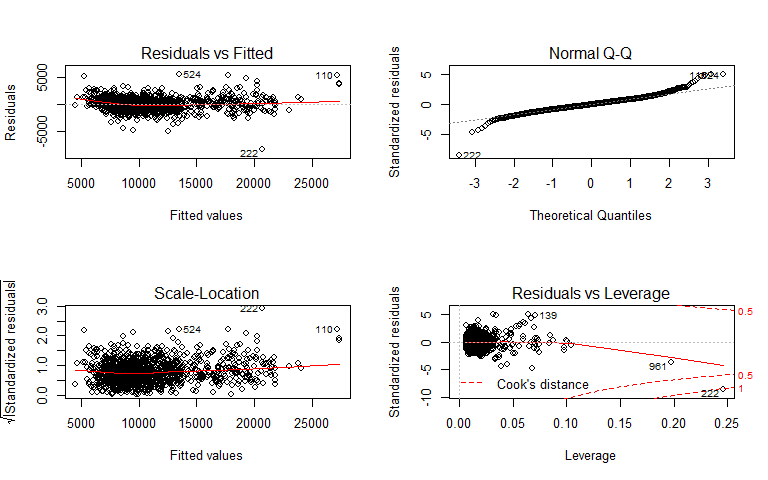

```r
par(mfrow=c(2,2))
plot(fit2)
```

```r
par(mfrow=c(1,1))
```

### Normality:

```r
Res=resid(fit2)
highchart() %>%
  hc_add_series_density(density(Res)) %>%
  hc_title(text="Residual values' Distribution") %>%
  hc_yAxis(title = list(text = "Probability")) %>%
  hc_xAxis(title = list(text = "Residual"))
```

[interactive chart not shown]

We have assumed that the reponse variable is sampled form normal distribution. If so, the residual values should have a normal distribution around 0. The Q-Q plot shows the standardized residuals against the values of residues if the response variable was normal. If the normality assumption is right, then all the point should belong to the 45 degree straight line, else, the assumption has been false.

Neglecting the few points on the edges of the plot, The plot shows that we haven’t violated the normality assumption eventhough Some of the variables we’re using, Such as BoardComputer are binomial.

**Normality Assumption: True**

### Independence

Using the diagnostic plots above, we can’t tell whether the price values are independent. This assumption is usually violated when $Y$ is a timeseries variable and $Y_n$ depends on $Y_n_-_1$. We’ll use a Durbin-wastson Test to findout if theres an autocorrelation between error values, meaning that the independence assumpution is false.

```r
# Test for Autocorrelated Errors
dwtest(fit2)
```

```
##
##  Durbin-Watson test
##
## data:  fit2
## DW = 1.7127, p-value = 1.44e-08
## alternative hypothesis: true autocorrelation is greater than 0
```

### Homoscedasticity

**Homoscedasticity Assumption: True**

## 8. Linear Model Sufficiency & Higher Orders

```r
pcar<-select(car,Id,Price,Age,KM,Weight,Boardcomputer)
pfit<-lm(Price ~ polym(Age,KM,Weight,Boardcomputer,degree=2, raw=TRUE),pcar)
summary(pfit)
```

```
##
## Call:
## lm(formula = Price ~ polym(Age, KM, Weight, Boardcomputer, degree = 2,
##     raw = TRUE), data = pcar)
##
## Residuals:
##     Min      1Q  Median      3Q     Max
## -7096.2  -673.1   -26.9   699.1  6804.6
##
## Coefficients: (1 not defined because of singularities)
##                                                                        Estimate
## (Intercept)                                                          -5.565e+04
## polym(Age, KM, Weight, Boardcomputer, degree = 2, raw = TRUE)1.0.0.0  1.231e+02
## polym(Age, KM, Weight, Boardcomputer, degree = 2, raw = TRUE)2.0.0.0  7.402e-01
## polym(Age, KM, Weight, Boardcomputer, degree = 2, raw = TRUE)0.1.0.0  3.737e-03
## polym(Age, KM, Weight, Boardcomputer, degree = 2, raw = TRUE)1.1.0.0  5.296e-04
## polym(Age, KM, Weight, Boardcomputer, degree = 2, raw = TRUE)0.2.0.0 -7.466e-08
## polym(Age, KM, Weight, Boardcomputer, degree = 2, raw = TRUE)0.0.1.0  1.091e+02
## polym(Age, KM, Weight, Boardcomputer, degree = 2, raw = TRUE)1.0.1.0 -3.309e-01
## polym(Age, KM, Weight, Boardcomputer, degree = 2, raw = TRUE)0.1.1.0 -3.871e-05
## polym(Age, KM, Weight, Boardcomputer, degree = 2, raw = TRUE)0.0.2.0 -3.427e-02
## polym(Age, KM, Weight, Boardcomputer, degree = 2, raw = TRUE)0.0.0.1 -1.327e+04
## polym(Age, KM, Weight, Boardcomputer, degree = 2, raw = TRUE)1.0.0.1  5.633e+01
## polym(Age, KM, Weight, Boardcomputer, degree = 2, raw = TRUE)0.1.0.1 -5.035e-03
## polym(Age, KM, Weight, Boardcomputer, degree = 2, raw = TRUE)0.0.1.1  1.031e+01
## polym(Age, KM, Weight, Boardcomputer, degree = 2, raw = TRUE)0.0.0.2         NA
##                                                                      Std. Error
## (Intercept)                                                           8.609e+03
## polym(Age, KM, Weight, Boardcomputer, degree = 2, raw = TRUE)1.0.0.0  8.051e+01
## polym(Age, KM, Weight, Boardcomputer, degree = 2, raw = TRUE)2.0.0.0  2.123e-01
## polym(Age, KM, Weight, Boardcomputer, degree = 2, raw = TRUE)0.1.0.0  2.640e-02
## polym(Age, KM, Weight, Boardcomputer, degree = 2, raw = TRUE)1.1.0.0  1.027e-04
## polym(Age, KM, Weight, Boardcomputer, degree = 2, raw = TRUE)0.2.0.0  1.863e-08
## polym(Age, KM, Weight, Boardcomputer, degree = 2, raw = TRUE)0.0.1.0  1.224e+01
## polym(Age, KM, Weight, Boardcomputer, degree = 2, raw = TRUE)1.0.1.0  6.152e-02
## polym(Age, KM, Weight, Boardcomputer, degree = 2, raw = TRUE)0.1.1.0  2.282e-05
## polym(Age, KM, Weight, Boardcomputer, degree = 2, raw = TRUE)0.0.2.0  4.373e-03
## polym(Age, KM, Weight, Boardcomputer, degree = 2, raw = TRUE)0.0.0.1  2.871e+03
## polym(Age, KM, Weight, Boardcomputer, degree = 2, raw = TRUE)1.0.0.1  1.168e+01
## polym(Age, KM, Weight, Boardcomputer, degree = 2, raw = TRUE)0.1.0.1  3.378e-03
```

[output cut: 41 more lines]

```
## polym(Age, KM, Weight, Boardcomputer, degree = 2, raw = TRUE)0.0.1.0 ***
## polym(Age, KM, Weight, Boardcomputer, degree = 2, raw = TRUE)1.0.1.0 ***
## polym(Age, KM, Weight, Boardcomputer, degree = 2, raw = TRUE)0.1.1.0 .
## polym(Age, KM, Weight, Boardcomputer, degree = 2, raw = TRUE)0.0.2.0 ***
## polym(Age, KM, Weight, Boardcomputer, degree = 2, raw = TRUE)0.0.0.1 ***
## polym(Age, KM, Weight, Boardcomputer, degree = 2, raw = TRUE)1.0.0.1 ***
## polym(Age, KM, Weight, Boardcomputer, degree = 2, raw = TRUE)0.1.0.1
## polym(Age, KM, Weight, Boardcomputer, degree = 2, raw = TRUE)0.0.1.1 ***
## polym(Age, KM, Weight, Boardcomputer, degree = 2, raw = TRUE)0.0.0.2
## ---
## Signif. codes:  0 '***' 0.001 '**' 0.01 '*' 0.05 '.' 0.1 ' ' 1
##
## Residual standard error: 1194 on 1422 degrees of freedom
## Multiple R-squared:  0.8925, Adjusted R-squared:  0.8915
## F-statistic: 908.5 on 13 and 1422 DF,  p-value: < 2.2e-16
```

```r
highchart() %>%
  hc_add_series_scatter(x=pcar$Price,y=round(fitted(pfit)),name="Linear Model",showInLegend = T) %>%
  hc_title(text="Polynomial Model") %>%
  hc_yAxis(title = list(text = "Estimated Price")) %>%
  hc_xAxis(title = list(text = "Actual Price")) %>%
  hc_add_series_scatter(x=pcar$Price,y=pcar$Price,name="Actual Data Points",showInLegend = T)
```

[interactive chart not shown]

## 9. Predict The Output For The New Dataset

We fit the model on half of the data and then, evaluate the predicted price for the other half.

```r
#Creating Test and Training Data:
Test <- car[sample(x=car$Id,size=length(car$Id)/2,replace = FALSE),]
car %>% filter(! Id %in% Test$Id)->Train

Redun = c("Model","Age", "Met_Color",
           "Color","cc","Doors","Cylinders","Gears","Airbag_1","Airbag_2",
           "Central_Lock","Power_Steering","Radio","Mistlamps","Radio_cassette")

Test<-Test[ , !(names(Test) %in% Redun)]
Train<-Train[ , !(names(Train) %in% Redun)]

# Fitting on the Training Data
valfit <- lm(Price~.-Id,Train)

#predicting Price for the Test Data
Predict <- predict(valfit,newdata = Test)

#Calculating Normalized Error
MeanP=round(mean(Test$Price))
Test[,"Predict"]<-Predict
Test %>% mutate(SE=(Predict-Price)^2,NormErr=(Predict-Price)^2/Price^2)->Test

SSE=sum(Test$SE,na.rm=T)
MeanNormEr = round(mean(Test$NormErr,na.rm=T),3)
```

The Sum of Squared Prediction Errors is about *926215490* dollars squared. This doesn’t give us a good sense of how the data is predicted. I’ve calculated the normalized prediction error for each of the cars in the test data. Distribution of this normalized Error with a mean value of *0.014*, is plotted below.

```r
highchart() %>%
  hc_add_series_density(density(Test$NormErr,na.rm=T),name="Normalized Error Distribution")
```

[interactive chart not shown]

We can see that the error is about 1% which is suitable for us. For a better understanding, Let’s plot the actual prices and predicted ones.

```r
highchart() %>%
  hc_add_series_scatter(x=Test$Price,y=Test$Predict,name="Actual Prices") %>%
  hc_add_series_scatter(x=Test$Price,y=Test$Price,name="Predicted Price") %>%
  hc_title(text="Car Prices vs. Model Estimated Prices") %>%
  hc_yAxis(title = list(text = "Predicted Price")) %>%
  hc_xAxis(title = list(text = "Actual Price"))
```

[interactive chart not shown]

## 10. Cross Validation

We’ll use a 5-fold cross validation method to findout how accurate our model is. Using CVlm in the DAAG Library we have:

```r
carval <- car[ , !(names(car) %in% Redun)]

#CVlm(data = carval, form.lm = formula(Price~.-Id), m = 5,
 #            seed=435, dots = FALSE, plotit = c("Observed","Residual"),
 #            main="cross-validation predicted values", legend.pos="topleft", printit = F)
```

```r
require(caret)
flds <- createFolds(car$Id, k = 5, list = TRUE, returnTrain = FALSE)
SSE=integer()
MeanNormEr=integer()

for(i in 1:5){
  index=unlist(flds[i])
  train <- carval[ -index,]
  test <- carval[index,]

  valfit <- lm(Price~.-Id,train)

#predicting Price for the Test Data
  Predict <- predict(valfit,newdata = test)

#Calculating Normalized Error
  MeanP=round(mean(test$Price))
  test[,"Predict"]<-Predict
  test %>% mutate(SE=(Predict-Price)^2,NormErr=(Predict-Price)^2/Price^2)->test

  #calculating 2 types of error
  SSE[i]=sum(test$SE,na.rm=T)
  MeanNormEr[i] = round(mean(test$NormErr,na.rm=T),3)

}
names(SSE)<-c("1st Iteration SSE","2nd Iteration SSE","3rd Iteration SSE","4th Iteration SSE","5th Iteration SSE")
names(MeanNormEr)<-c("1st Iteration NSE","2nd Iteration NSE","3rd Iteration NSE","4th Iteration NSE","5th Iteration NSE")

SSE
```

```
## 1st Iteration SSE 2nd Iteration SSE 3rd Iteration SSE 4th Iteration SSE
##         325015862         295857434         326038948         407449819
## 5th Iteration SSE
##         505228209
```

```r
MeanNormEr
```

```
## 1st Iteration NSE 2nd Iteration NSE 3rd Iteration NSE 4th Iteration NSE
##             0.014             0.010             0.013             0.015
## 5th Iteration NSE
##             0.018
```

The vectors *SSE* and *MeanNormEr* show that we have predicted the test data everytime with less than 2% error with is satisfying. This indicates that our model works well for the data as well as predicting new variables.